# Lab 11 All Stars

## Johnny Tamanaha

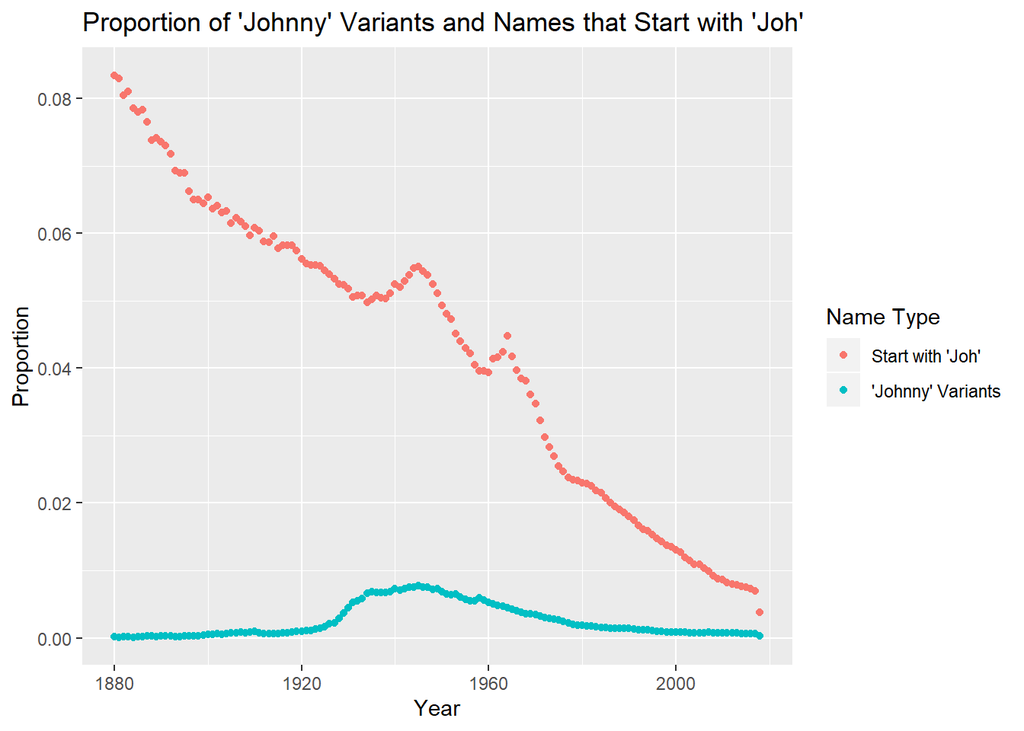

The regular expression I used for my name was ^Jo[ah]?[n]+ie[y]*$. There has been a small steady decline of Johnnys since my birth year. Other names that start with Joh have been on a heavy decline from 1880 to 2018, so my name has become relatively more popular in comparison to those names.

### Ariel and Rachel Regexs

```
## # A tibble: 8 x 3
## # Groups:   year [4]
##    year initial variants
##   <dbl> <chr>      <int>
## 1  1973 A              2
## 2  1973 R             13
## 3  1988 A             10
## 4  1988 R             16
## 5  1990 A             11
## 6  1990 R             16
## 7  2018 A              7
## 8  2018 R              7
```

```
## # A tibble: 4 x 2
##    year prop_A_R
##   <dbl>    <dbl>
## 1  1973  0.00542
## 2  1988  0.0112
## 3  1990  0.0126
## 4  2018  0.00134
```

The first table shows the number of versions of the names Ariel or Rachel for each year, and the second table shows the chances that a girl would have either of those names for each year.

### The Little Mermaid Effect

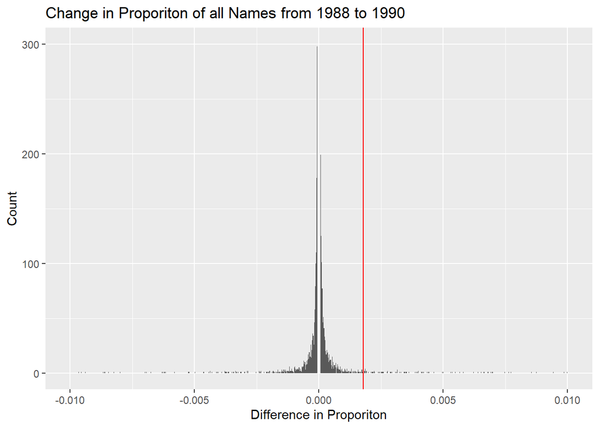